# Course Project: Writeup

Pinchuk Maria

Sunday, April 26, 2015

```r
train <- read.csv("C:/Users/HOME/Documents/pml-training.csv", header=TRUE, na.strings=c("NA","#DIV/0!"))
test <- read.csv("C:/Users/HOME/Documents/pml-testing.csv", header=TRUE, na.strings=c("NA","#DIV/0!"))
```

To begin with I will load some necessary packages

```r
library(caret)
library(rpart)
```

```r
library(rpart.plot)
library(randomForest)
library(gridExtra)
library(rattle)
library(e1071)
set.seed(12345)
```

Getting ridding of columns with NA

```r
train<-train[,colSums(is.na(train)) == 0]
test <-test[,colSums(is.na(test)) == 0]
```

#### Dividing the training data into 2 to allow cross-validation

A little bit decribing: The training data set includes 160 variables and 19622 observations The testing data set includes 160 variables and 20 obs. To produce cross-validation, the training data set is partionned into 2 sets: subTraining (70%) and subTest (30%). This will be performed using random subsampling without replacement.

```r
set.seed(12345)
InTraining <- createDataPartition(y=train$classe, p=0.70, list=FALSE)
subset_Training <- train[InTraining, ]
subset_Testing <- train[-InTraining, ]
```

About variable “classe”: it includes A, B, C, D and E levels. A plot of the outcome variable allows to look at the frequency of every level in the subset_Training data.

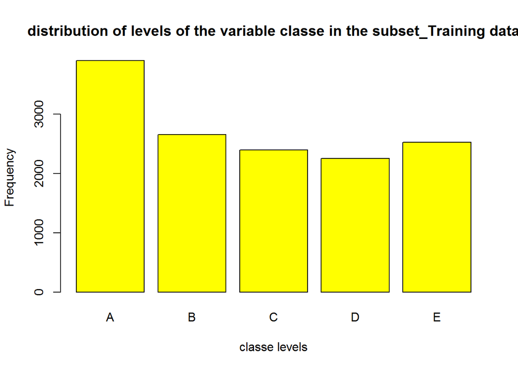

```r
plot(subset_Training$classe, col="yellow", main="distribution of levels of the variable classe in the subset_Training data", xlab="classe levels", ylab="Frequency")
```

#### Decision tree

```r
DesTree <- rpart(classe ~ ., data=subset_Training, method="class")
predict <- predict(DesTree, subset_Testing, type = "class")
```

###### Plotting the decision trees

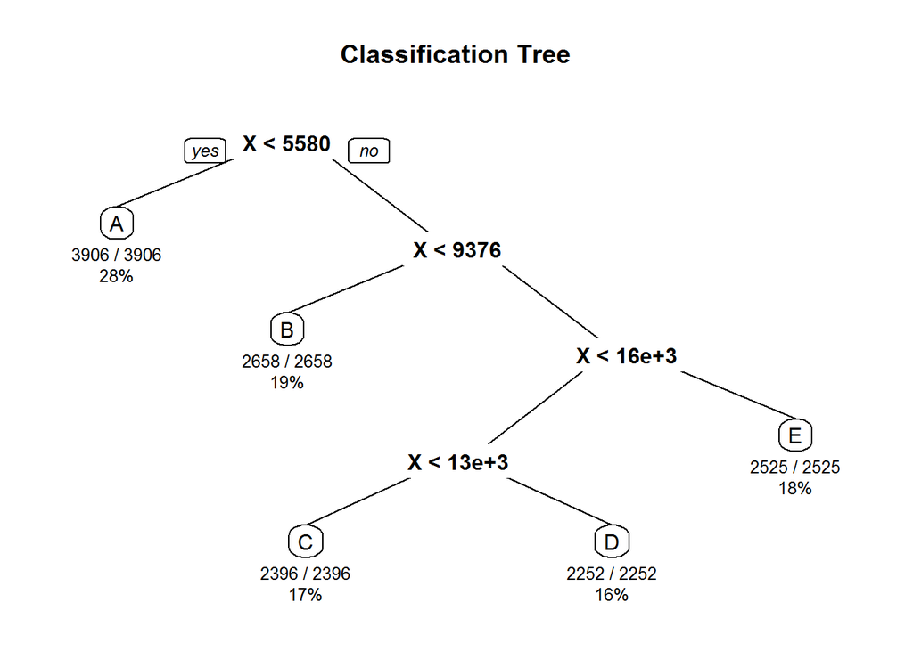

```r
rpart.plot(DesTree, main="Classification Tree", extra=102, under=TRUE)
```

###### Results of test on subset_testing data

```r
confusionMatrix(predict, subset_Testing$classe)
```

```
## Confusion Matrix and Statistics
##
##           Reference
## Prediction    A    B    C    D    E
##          A 1673    0    0    0    0
##          B    1 1138    0    0    0
##          C    0    1 1026    1    0
##          D    0    0    0  963    0
##          E    0    0    0    0 1082
##
## Overall Statistics
##
##                Accuracy : 0.9995
##                  95% CI : (0.9985, 0.9999)
##     No Information Rate : 0.2845
##     P-Value [Acc > NIR] : < 2.2e-16
##
##                   Kappa : 0.9994
##  Mcnemar's Test P-Value : NA
##
## Statistics by Class:
##
##                      Class: A Class: B Class: C Class: D Class: E
## Sensitivity            0.9994   0.9991   1.0000   0.9990   1.0000
## Specificity            1.0000   0.9998   0.9996   1.0000   1.0000
## Pos Pred Value         1.0000   0.9991   0.9981   1.0000   1.0000
## Neg Pred Value         0.9998   0.9998   1.0000   0.9998   1.0000
## Prevalence             0.2845   0.1935   0.1743   0.1638   0.1839
## Detection Rate         0.2843   0.1934   0.1743   0.1636   0.1839
## Detection Prevalence   0.2843   0.1935   0.1747   0.1636   0.1839
## Balanced Accuracy      0.9997   0.9995   0.9998   0.9995   1.0000
```

#### Another prediction model (Random Forest)

```r
RandFor <- randomForest(classe ~. , data=subset_Training)
predict2 <- predict(RandFor, subset_Testing, type = "class")
```

###### Results of test on subset_testing data

```r
confusionMatrix(predict2, subset_Testing$classe)
```

```
## Confusion Matrix and Statistics
##
##           Reference
## Prediction    A    B    C    D    E
##          A 1674    0    0    0    0
##          B    0 1139    0    0    0
##          C    0    0 1026    0    0
##          D    0    0    0  964    0
##          E    0    0    0    0 1082
##
## Overall Statistics
##
##                Accuracy : 1
##                  95% CI : (0.9994, 1)
##     No Information Rate : 0.2845
##     P-Value [Acc > NIR] : < 2.2e-16
##
##                   Kappa : 1
##  Mcnemar's Test P-Value : NA
##
## Statistics by Class:
##
##                      Class: A Class: B Class: C Class: D Class: E
## Sensitivity            1.0000   1.0000   1.0000   1.0000   1.0000
## Specificity            1.0000   1.0000   1.0000   1.0000   1.0000
## Pos Pred Value         1.0000   1.0000   1.0000   1.0000   1.0000
## Neg Pred Value         1.0000   1.0000   1.0000   1.0000   1.0000
## Prevalence             0.2845   0.1935   0.1743   0.1638   0.1839
## Detection Rate         0.2845   0.1935   0.1743   0.1638   0.1839
## Detection Prevalence   0.2845   0.1935   0.1743   0.1638   0.1839
## Balanced Accuracy      1.0000   1.0000   1.0000   1.0000   1.0000
```

#### Making choice

Random Forest algorithm performed a little bit better than Decision Trees. I choose random Forest model.